# 用R进行市场调查和消费者感知分析

林荟

2016-07-20

# 介绍

- 幻灯片 & R代码：http://scientistcafe.com
- 什么是数据科学家
  - 澄清定义：行业现状，分布，教育技能要求等
  - http://www.xueqing.tv/course/55
- 用R做数据预处理
  - 数据分析的一般流程：问题到数据，数据到信息，信息到价值
  - http://www.xueqing.tv/course/66
- 数据整合操作和建模辅助技术
  - http://www.xueqing.tv/course/67
- 用R进行市场调查和消费者感知分析
  - 相对完整的分析框架
  - 理解数据分析的一般流程

# 数据分析一般流程

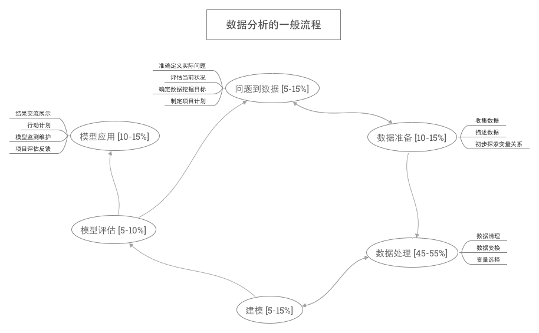

# 问题到数据-理解问题

- 理解客户的问题：谁是客户（某航空公司）？交流，交流，交流！
- 问题要具体
  - 某航空公司: 乘客体验如何？哪方面需要提高？
  - 类别：比较、描述、聚类，判别还是回归
  - 需要什么样的数据：现有数据，数据质量，需要收集的数据，自变量，因变量
  - 哪些方面的满意度？哪些主要竞争对手？
  - 内部数据？外部数据？

# 问题到数据-设计问卷

礼貌（Courtesy）  
友善（Friendliness）  
能够提供需要的帮助（Helpfulness）  
食物饮料服务（Service）  
购票容易度（Easy_Reservation）  
座椅选择（Preferred_Seats）  
航班选择（Flight_Options）  
票价（Ticket_Prices）  
座椅舒适度（Seat_Comfort）  
位置前后空间（Seat_Roominess）  
随机行李存放（Overhead_Storage）  
机舱清洁（Clean_Aircraft）  
总体满意度（Satisfaction）  
再次选择次航空公司（Fly_Again）  
向朋友推荐此航空公司（Recommend）

# 数据到信息

- 流程图：数据准备，数据清理，建模和模型评估
- 数据预处理：清理、变换、缺失值填补等 （非常重要且耗时）
- 建模和评估：
  - 分析用户感知：特征提取
  - PCA，EFA
  - **评估标准**

# 数据到信息-数据

```
## Observations: 3,000
## Variables: 17
## $ Easy_Reservation <int> 6, 5, 6, 5, 4, 5, 6, 4, 6, 4, 5, 5, 6, 5, 5, ...
## $ Preferred_Seats  <int> 5, 7, 6, 6, 5, 6, 6, 6, 5, 4, 7, 5, 7, 6, 6, ...
## $ Flight_Options   <int> 4, 7, 5, 5, 3, 4, 6, 3, 4, 5, 6, 6, 6, 5, 6, ...
## $ Ticket_Prices    <int> 5, 6, 6, 5, 6, 5, 5, 5, 5, 6, 7, 7, 6, 7, 7, ...
## $ Seat_Comfort     <int> 5, 6, 7, 7, 6, 6, 6, 4, 6, 9, 7, 7, 6, 6, 6, ...
## $ Seat_Roominess   <int> 7, 8, 6, 8, 7, 8, 6, 5, 7, 8, 8, 9, 7, 8, 6, ...
## $ Overhead_Storage <int> 5, 5, 7, 6, 5, 4, 4, 4, 5, 7, 6, 6, 7, 5, 4, ...
## $ Clean_Aircraft   <int> 7, 6, 7, 7, 7, 7, 6, 4, 6, 7, 7, 7, 7, 7, 6, ...
## $ Courtesy         <int> 5, 6, 6, 4, 2, 5, 5, 4, 5, 6, 4, 6, 4, 5, 5, ...
## $ Friendliness     <int> 4, 6, 6, 6, 3, 4, 5, 5, 4, 5, 6, 7, 5, 4, 4, ...
## $ Helpfulness      <int> 6, 5, 6, 4, 4, 5, 5, 4, 3, 5, 5, 6, 5, 4, 5, ...
## $ Service          <int> 6, 5, 6, 5, 3, 5, 5, 5, 3, 5, 6, 6, 5, 5, 4, ...
## $ Satisfaction     <int> 6, 7, 7, 5, 4, 6, 5, 5, 4, 7, 6, 7, 6, 4, 4, ...
## $ Fly_Again        <int> 6, 6, 6, 7, 4, 5, 3, 4, 7, 6, 8, 6, 5, 4, 6, ...
## $ Recommend        <int> 3, 6, 5, 5, 4, 5, 6, 5, 8, 6, 8, 7, 6, 5, 6, ...
## $ ID               <int> 1, 2, 3, 4, 5, 6, 7, 8, 9, 10, 11, 12, 13, 14...
## $ Airline          <fctr> AirlineCo.1, AirlineCo.1, AirlineCo.1, Airli...
```

# 数据到信息-检查相关性

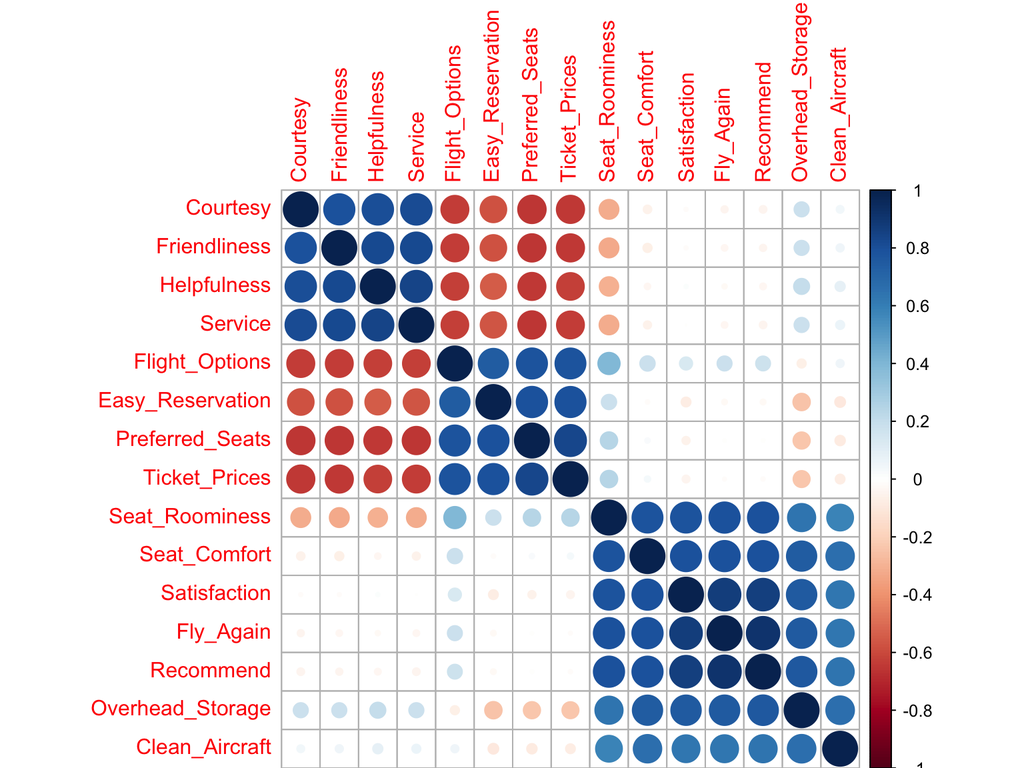

# 数据到信息-主成分分析

```r
airline.pc<-select(airline,Easy_Reservation:Recommend)%>%
  prcomp()
summary(airline.pc)
```

```
## Importance of components:
##                          PC1    PC2     PC3     PC4     PC5     PC6
## Standard deviation     4.693 4.2836 1.68335 1.03625 0.88896 0.82333
## Proportion of Variance 0.435 0.3624 0.05596 0.02121 0.01561 0.01339
## Cumulative Proportion  0.435 0.7974 0.85338 0.87458 0.89019 0.90358
##                            PC7     PC8     PC9    PC10    PC11    PC12
## Standard deviation     0.80349 0.78694 0.77536 0.77020 0.74612 0.71831
## Proportion of Variance 0.01275 0.01223 0.01187 0.01172 0.01099 0.01019
## Cumulative Proportion  0.91633 0.92856 0.94043 0.95215 0.96314 0.97333
##                           PC13    PC14    PC15
## Standard deviation     0.69417 0.66650 0.65131
## Proportion of Variance 0.00952 0.00877 0.00838
## Cumulative Proportion  0.98285 0.99162 1.00000
```

# 数据到信息-主成分分析陡坡图

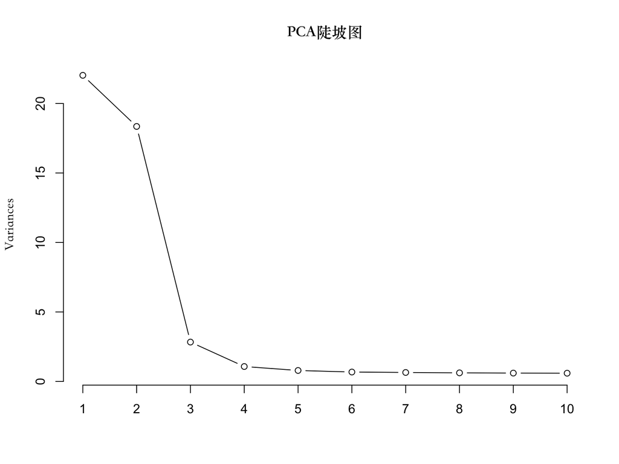

# 数据到信息-主成分分析双标图

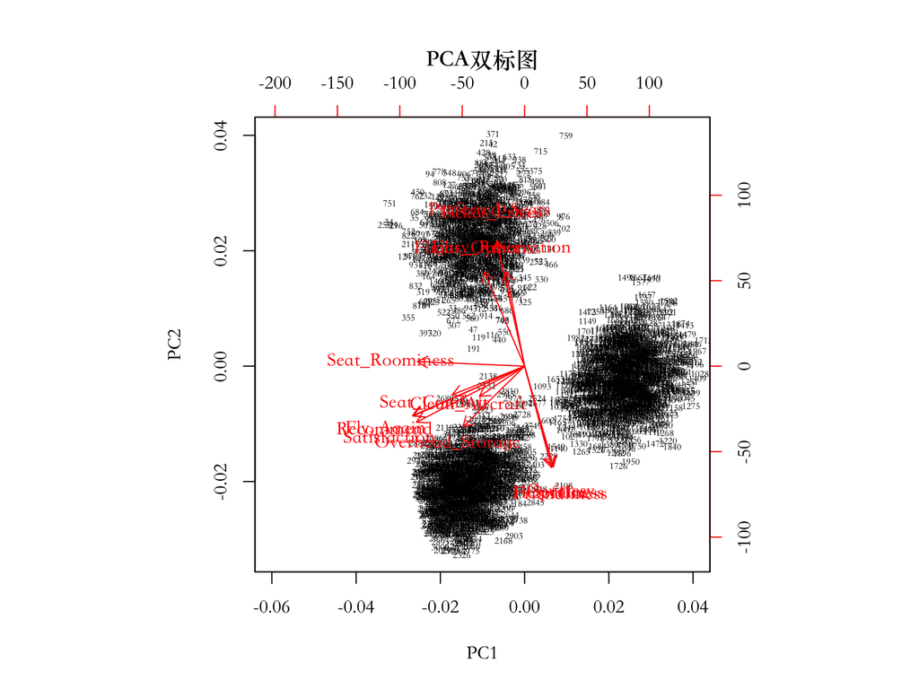

# 数据到信息-数据聚合

```
## Observations: 3
## Variables: 16
## $ Airline          <fctr> AirlineCo.1, AirlineCo.2, AirlineCo.3
## $ Easy_Reservation <dbl> 5.031, 2.939, 2.038
## $ Preferred_Seats  <dbl> 6.025, 2.995, 2.019
## $ Flight_Options   <dbl> 4.996, 2.033, 2.067
## $ Ticket_Prices    <dbl> 5.997, 3.016, 2.058
## $ Seat_Comfort     <dbl> 6.988, 5.009, 7.918
## $ Seat_Roominess   <dbl> 7.895, 3.970, 7.908
## $ Overhead_Storage <dbl> 5.967, 4.974, 7.924
## $ Clean_Aircraft   <dbl> 6.947, 6.050, 7.882
## $ Courtesy         <dbl> 5.016, 7.937, 7.942
## $ Friendliness     <dbl> 4.997, 7.946, 7.914
## $ Helpfulness      <dbl> 5.017, 7.962, 7.954
## $ Service          <dbl> 5.019, 7.956, 7.906
## $ Satisfaction     <dbl> 5.944, 3.011, 7.903
## $ Fly_Again        <dbl> 5.983, 3.008, 7.920
## $ Recommend        <dbl> 6.008, 2.997, 7.929
```

# 数据到信息-聚合后双标图

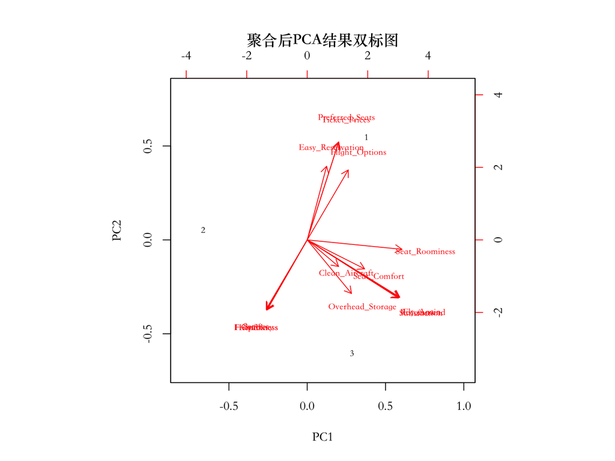

# 数据到信息-可视化

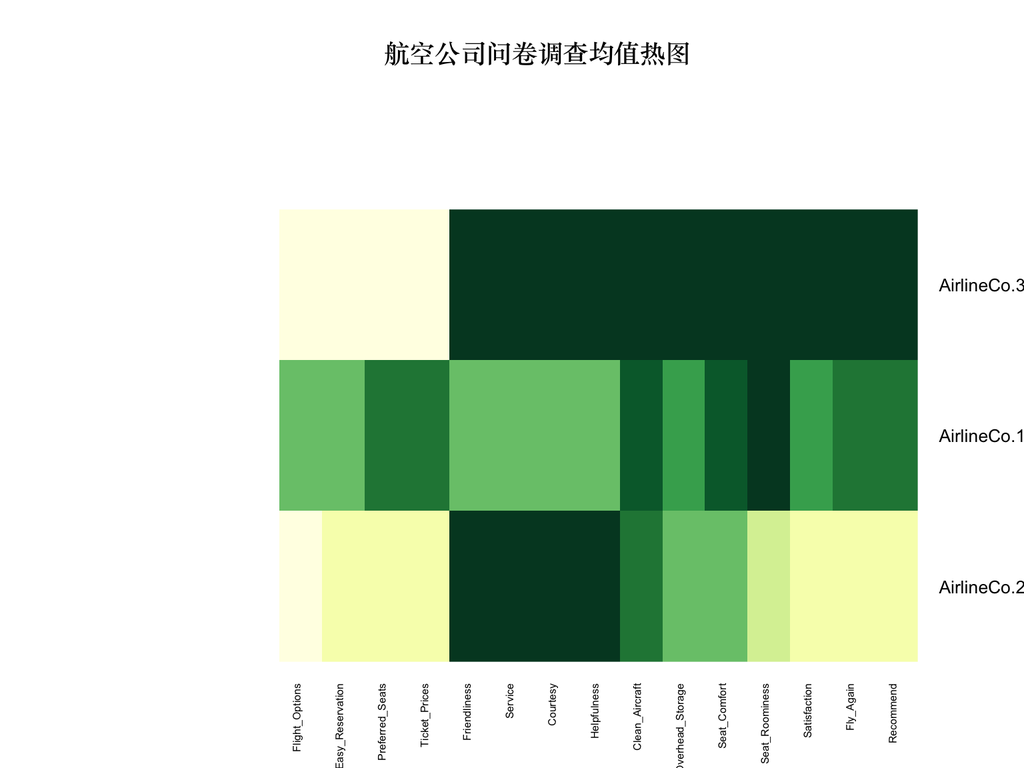

# 数据到信息-探索性因子分析（EFA）

- 获取抽样调查中问题之间的构造
- 结果是一个因子矩阵，其目标是使一小部分变量对应较高的因子载荷，其余的因子载荷都很低
- 为什么用因子分析：
  - 使结果可实践，PCA很难实现
  - 优化调查项，保留因子载荷高的项
  - 探索调查项之间的联系是不是符合我们的期待

# 数据到信息-探索性因子分析（EFA）

```html
Loadings:
                 Factor1 Factor2 Factor3
Easy_Reservation                  0.941
Preferred_Seats                   0.880
Flight_Options    0.167           0.803
Ticket_Prices                     0.887
Seat_Comfort      0.865
Seat_Roominess    0.844  -0.242
Overhead_Storage  0.833   0.137  -0.142
Clean_Aircraft    0.708
Courtesy                  0.818
Friendliness              0.868
Helpfulness               0.953
Service                   0.922
Satisfaction      0.921
Fly_Again         0.943
Recommend         0.942
```

# 数据到信息-因子载荷热图

Factor 1: 乘客的总体感觉  
Factor 2: 机舱服务感知  
Factor 3: 购票体验感知

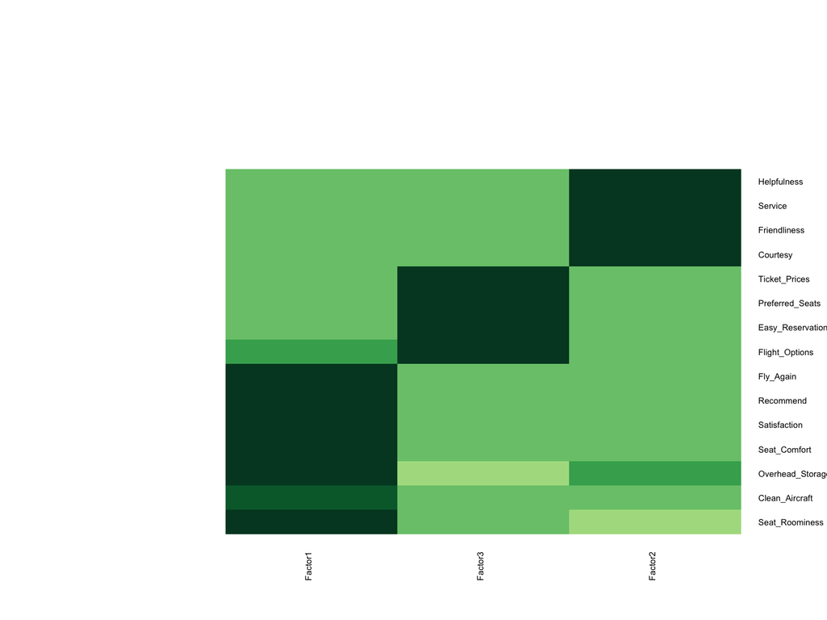

# 数据到信息-平均因子分值热图

Factor 1: 乘客的总体感觉  
Factor 2: 机舱服务感知  
Factor 3: 购票体验感知

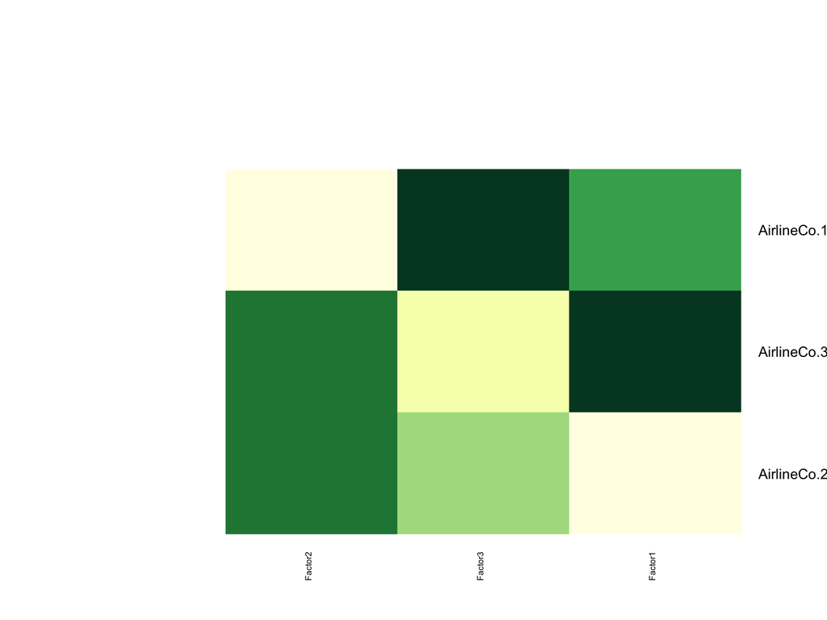

# 数据到信息-信息

# 信息到行动

- 行业知识：
  - 解释购票体验和空航服务体验的关系
- 信息的接收者：哪些人员真正实践这些改进？交流、倾听和尊重
- 讲故事的能力

**预告：** - 下周六晚上 郎大为会给大家介绍 REmap 就是一个用R语言生成echarts图的包 - http://www.xueqing.tv/cms/article/10